# Pollen_Microbe

```r
library(tidyverse)
library(janitor)
library(naniar)
library(lubridate)
```

#pollen_micriobe dataset

```r
pollen_micriobe<-read_csv("doi_10_25338_B8BS75__v20210727/pollen_microbe_data.csv")%>%
  clean_names()
glimpse(pollen_micriobe)
```

```
## Rows: 558
## Columns: 15
## $ microbe_group         <chr> "Acinetobacter", "Acinetobacter", "Acinetobacter…
## $ microbetreatment      <chr> "362", "362", "362", "4422", "4422", "4422", "47…
## $ trial_date            <chr> "05.09.2019", "05.09.2019", "05.09.2019", "05.09…
## $ assay_replicate       <dbl> 1, 2, 3, 1, 2, 3, 1, 2, 3, 1, 2, 3, 1, 2, 3, 1, …
## $ timepoint             <dbl> 15, 15, 15, 15, 15, 15, 15, 15, 15, 15, 15, 15, …
## $ standardized_od_plate <dbl> 0.05, 0.05, 0.05, 0.05, 0.05, 0.05, 0.05, 0.05, …
## $ total_pollen          <dbl> 73, 63, 95, 49, 97, 79, 107, 92, 92, 84, 66, 71,…
## $ number_germ           <dbl> 0, 1, 0, 11, 6, 1, 0, 0, 0, 0, 1, 1, 0, 0, 0, 0,…
## $ number_burst          <dbl> 0, 0, 0, 0, 1, 1, 0, 0, 0, 0, 0, 0, 0, 0, 0, 0, …
## $ number_tip_burst      <dbl> 0, 0, 0, 0, 0, 0, 0, 0, 0, 0, 0, 0, 0, 0, 0, 0, …
## $ prop_germ             <dbl> 0.000, 0.016, 0.000, 0.224, 0.062, 0.013, 0.000,…
## $ prop_burst            <dbl> 0.000, 0.000, 0.000, 0.000, 0.010, 0.013, 0.000,…
## $ prop_tip_burst        <dbl> 0, 0, 0, 0, 0, 0, 0, 0, 0, 0, 0, 0, 0, 0, 0, 0, …
## $ allgerm               <dbl> 0.000, 0.016, 0.000, 0.224, 0.062, 0.013, 0.000,…
## $ allburst              <dbl> 0.000, 0.000, 0.000, 0.000, 0.010, 0.013, 0.000,…
```

```r
summary(pollen_micriobe)
```

```
##  microbe_group      microbetreatment    trial_date        assay_replicate
##  Length:558         Length:558         Length:558         Min.   :1.000
##  Class :character   Class :character   Class :character   1st Qu.:1.000
##  Mode  :character   Mode  :character   Mode  :character   Median :2.000
##                                                           Mean   :2.347
##                                                           3rd Qu.:3.000
##                                                           Max.   :4.000
##                                                           NA's   :36
##    timepoint     standardized_od_plate  total_pollen     number_germ
##  Min.   :15.00   Min.   :0.02500       Min.   : 14.00   Min.   : 0.000
##  1st Qu.:15.00   1st Qu.:0.02500       1st Qu.: 40.00   1st Qu.: 0.000
##  Median :45.00   Median :0.02500       Median : 67.50   Median : 1.000
##  Mean   :50.32   Mean   :0.03575       Mean   : 73.62   Mean   : 7.436
##  3rd Qu.:90.00   3rd Qu.:0.05000       3rd Qu.:100.00   3rd Qu.:10.000
##  Max.   :90.00   Max.   :0.05000       Max.   :187.00   Max.   :67.000
##                                                         NA's   :1
##   number_burst     number_tip_burst   prop_germ         prop_burst
##  Min.   : 0.0000   Min.   : 0.000   Min.   :0.00000   Min.   :0.0000
##  1st Qu.: 0.0000   1st Qu.: 0.000   1st Qu.:0.00000   1st Qu.:0.0000
##  Median : 0.0000   Median : 0.000   Median :0.02839   Median :0.0000
##  Mean   : 0.7504   Mean   : 1.205   Mean   :0.11322   Mean   :0.0099
##  3rd Qu.: 0.0000   3rd Qu.: 0.000   3rd Qu.:0.16125   3rd Qu.:0.0000
##  Max.   :56.0000   Max.   :33.000   Max.   :0.87100   Max.   :0.3040
##  NA's   :1         NA's   :85
##  prop_tip_burst       allgerm          allburst
##  Min.   :0.00000   Min.   :0.0000   Min.   :0.00000
##  1st Qu.:0.00000   1st Qu.:0.0000   1st Qu.:0.00000
##  Median :0.00000   Median :0.0285   Median :0.00000
##  Mean   :0.01251   Mean   :0.1253   Mean   :0.02233
##  3rd Qu.:0.00000   3rd Qu.:0.1820   3rd Qu.:0.01400
##  Max.   :0.30300   Max.   :0.9030   Max.   :0.32600
##
```

#distribution of microbe group - examine the distribution on each sample - find does one group having more samples than the other

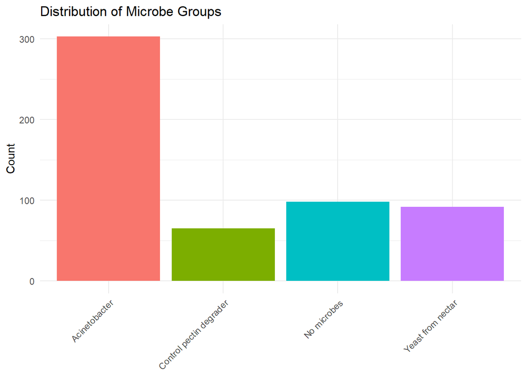

```r
pollen_micriobe %>%
  ggplot(aes(x=microbe_group, fill=microbe_group))+
  geom_bar()+
  theme_minimal()+
  labs(
    title="Distribution of Microbe Groups",
    x=NULL,
    y="Count")+
  theme(legend.position="none",
        axis.text.x=element_text(angle=45, hjust=1))
```

#microbe group and all germination - compare the germination of all microbe group - (according to the README allgerm; proportion of pollen grains that germinated, including both “number.germ” and “number.tip.burst ) - proportion germinated is calculated by number.germ/Total.pollen - include number tip burst give us more accurate overlooks on pollen initiated germination

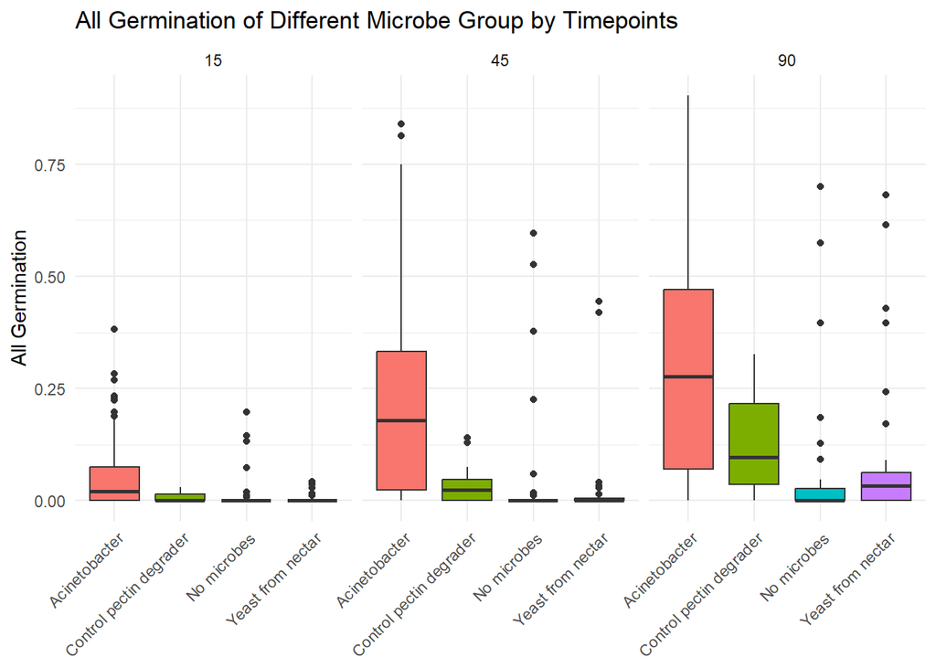

```r
pollen_micriobe%>%
  ggplot(aes(x=microbe_group,
             y=allgerm,
             fill=microbe_group))+
  geom_boxplot()+
  facet_wrap(~timepoint)+
  theme_minimal()+
  labs(
    title="All Germination of Different Microbe Group by Timepoints",
    x=NULL,
    y="All Germination")+
  theme(legend.position="none",
        axis.text.x=element_text(angle=45, hjust=1))
```

#microbe group and all germination(distribution) - examine how germination of each microbe group distributed - Acinetobacter; more variety in data

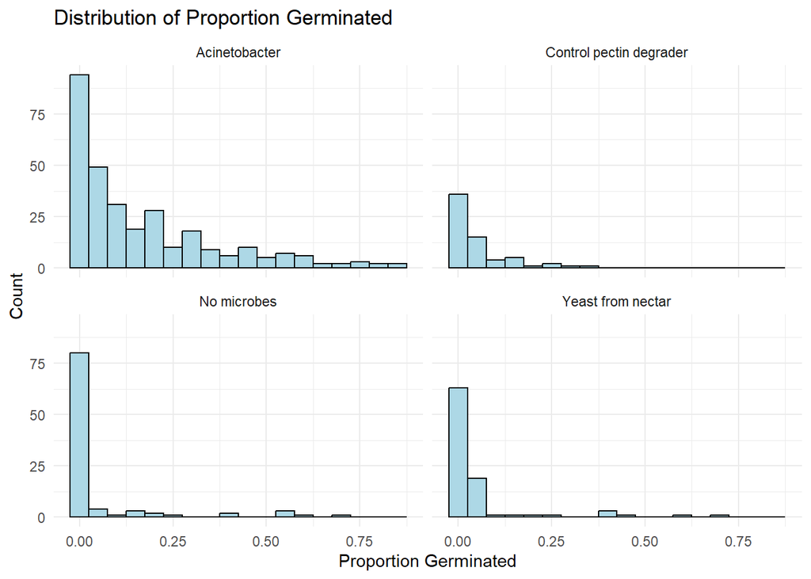

```r
pollen_micriobe%>%
  ggplot(aes(x=prop_germ))+
  geom_histogram(
    binwidth = 0.05,
    fill="lightblue",
    color="black")+
  theme_minimal()+
  facet_wrap(~microbe_group)+
  labs(
    title="Distribution of Proportion Germinated",
    x="Proportion Germinated",
    y="Count")
```

#microbe group and all burst - allburst; The proportion of pollen grains that expelled protoplasm into solution, including both “number.burst” and “number.tip.burst - which given pollen that burst/pollen released nutrients - by group the mean burst of Acinetobacter across all different time point is higher than other group

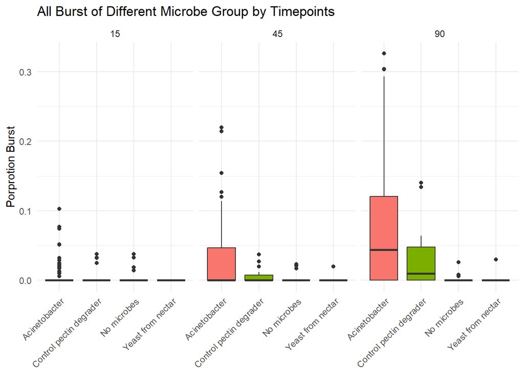

```r
pollen_micriobe%>%
  ggplot(aes(x=microbe_group, y=allburst, fill=microbe_group))+
  geom_boxplot()+
  facet_wrap(~timepoint)+
  theme_minimal()+
  labs(
    title="All Burst of Different Microbe Group by Timepoints",
    x=NULL,
    y="Porprotion Burst")+
  theme(legend.position="none",
        axis.text.x=element_text(angle=45, hjust=1))
```

#microbe group and all burst(distribution) - more burst in Acintebacter

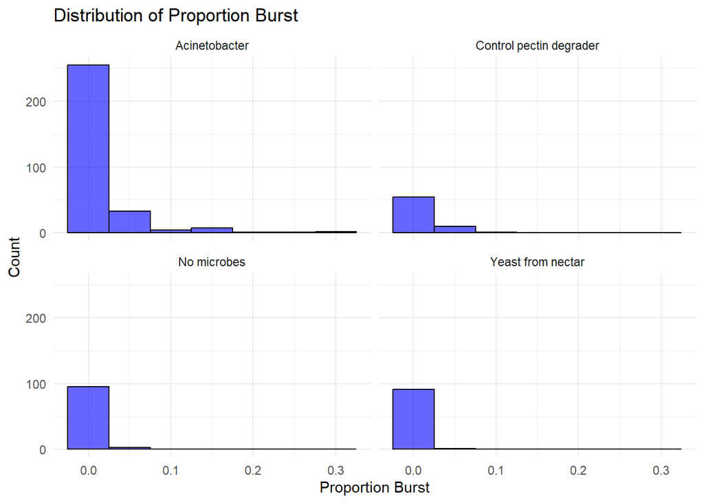

```r
pollen_micriobe%>%
  ggplot(aes(x=prop_burst))+
  geom_histogram(
    binwidth=0.05,
    fill="blue",
    color="black",
    alpha=0.6)+
  theme_minimal()+
  facet_wrap(~microbe_group)+
  labs(
    title="Distribution of Proportion Burst",
    x="Proportion Burst",
    y="Count")
```

#count timespot

```r
pollen_micriobe%>%
  count(timepoint)
```

```
## # A tibble: 3 × 2
##   timepoint     n
##       <dbl> <int>
## 1        15   183
## 2        45   187
## 3        90   188
```

#germination and time - check if longer time did cause larger germination —> does show

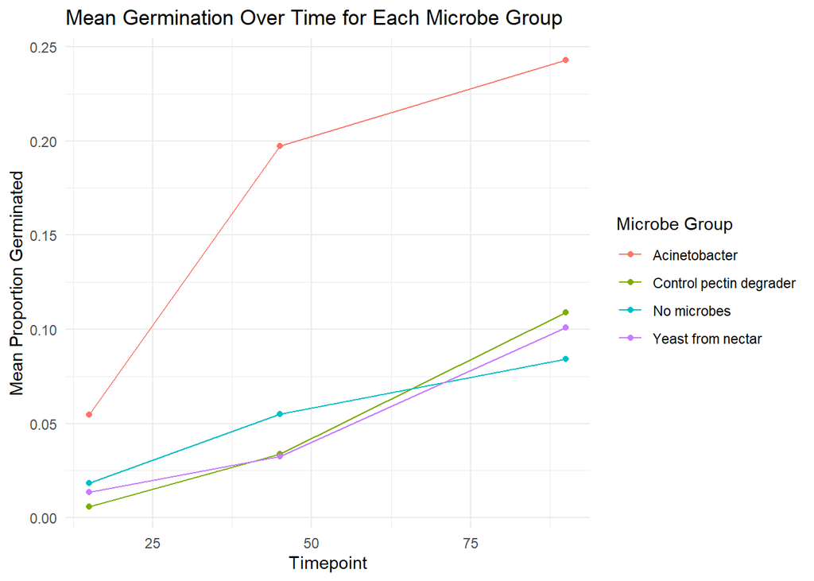

```r
pollen_micriobe%>%
  group_by(microbe_group, timepoint)%>%
  summarize(mean_germ = mean(prop_germ, na.rm = TRUE)) %>%
  ggplot(aes(x=timepoint,
             y=mean_germ,
             color=microbe_group))+
  geom_line()+
  geom_point()+
  theme_minimal()+
  labs(
    title="Mean Germination Over Time for Each Microbe Group",
    x="Timepoint",
    y="Mean Proportion Germinated",
    color="Microbe Group")
```

#standard OD & all germination - check how different OD changed germination - suggest larger OD and longer time point have greater germination

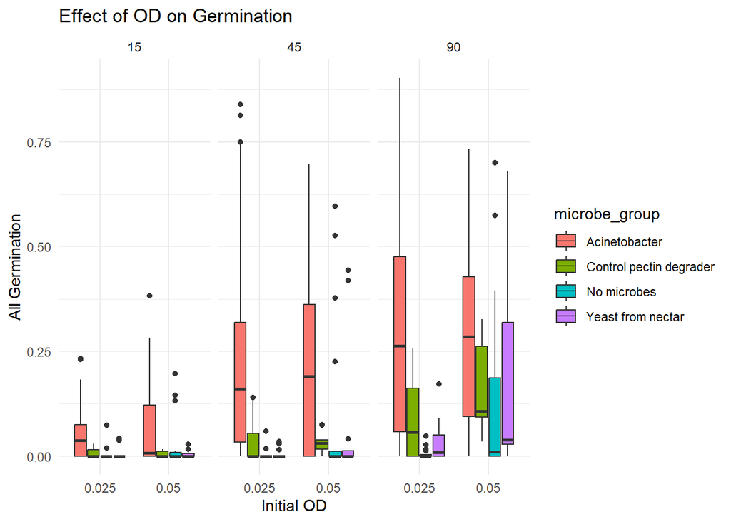

```r
pollen_micriobe%>%
  ggplot(aes(x=factor(standardized_od_plate),
             y=allgerm,
             fill=microbe_group))+
  geom_boxplot()+
  theme_minimal()+
  facet_wrap(~timepoint)+
  labs(
    title="Effect of OD on Germination",
    x="Initial OD",
    y="All Germination")
```